# Your Digest for Friday, Mar 15, 2024 11:59 PM

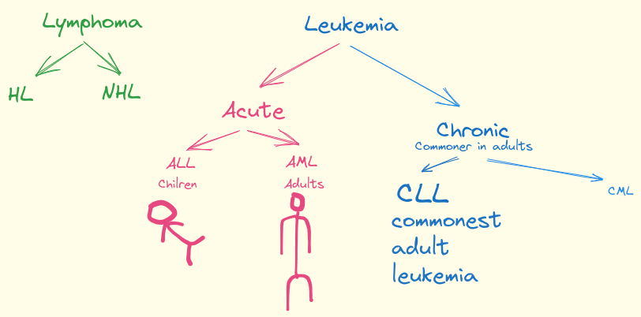

[output not shown]

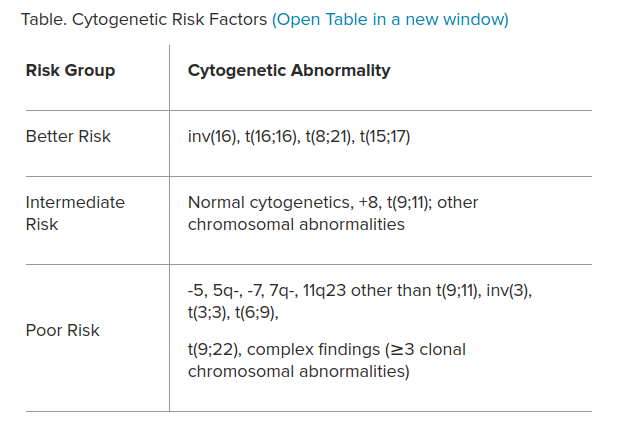

> Mnemonic: Catch the 9:22 train to philadelphia (clock - chronic)

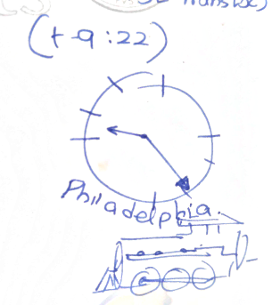

> Renal involvement is **one of the commonest** complications of multiple myeloma.(**50% incidence!**)
1. **Cast nephropathy:** Light chains -> freely filtered at glomerulus -> resorbed but resorbtive capacity exceeded in MM -> precipitate in the tubule in combination with Tamm-horsfall proteins-> **cast nephropathy**. *Usually presents as Acute or subacute kidney injury*.

> "LCDD must be differentiated from AL amyloidosis. LCDD is Congo red negative and is usually IF positive for κ rather than λ light chain. Moreover, **in LCDD the deposits are subendothelial and granular, whereas in amyloidosis they are composed of randomly arranged fibrils**."

> [!TIP] mnemonic: causes of MCD -> "minimal" = "invisible on LM" -> causes are I's
> - Idiopathic, Iatrogenic,Invasion (Malignancy),Infection, Industry (Mercury)

**Causes** of MCD:  
- Need to exclude **hepatitis B**, **SLE**, **thyroiditis**, some drugs (*penicillamine*, gold / *mercury*, **captopril**, NSAIDS) and **malignancy**.  
-

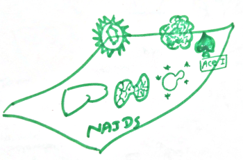

> [!TIP] Mnemonic i-PASTA / PATIS

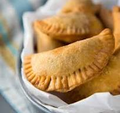

- Interferons
- D penicillamin
  - **Aminoglycosides**
- Tyrosine kinase inhibitors

> [!TIP] Mnemonic:  
> **Type 2 -> 2 = "Bi"**  
> Therefore, Type 2 is a defect of 'bicarbonate reabsorption'.  
> Type 4 = is in the DCT; makes sense that it's a defect in aldosterone action  
> Type 1 = H+ secretion defect in DCT.

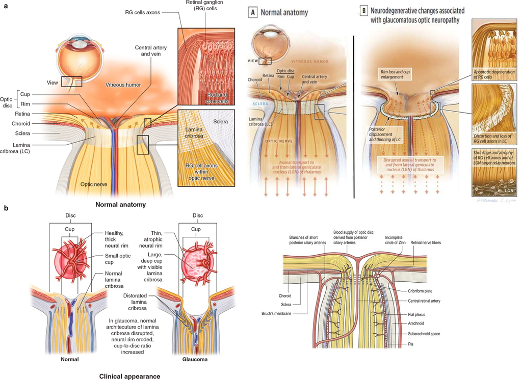

Causes of papilloedema

- space-occupying lesion: neoplastic, vascular
- malignant hypertension
- idiopathic intracranial hypertension
- hydrocephalus
- **hypercapnia**

Rare causes include

- hypoparathyroidism and *hypocalcaemia*
- vitamin A toxicity

> **mechanics** deal with lots of **viscous** fluids -> macroglobinaemia.  
> **W** in Waldenstrom -> **M** in IgM  
> Macro means large -> macro spleen and liver and macro lymph nodes  
> [!INFO] hyperviscosity syndrome (HVS)  
> The clinical presentation in HVS consists principally of the triad of
> 1. **mucosal bleeding,
> 2. visual changes,
> 3. and neurologic symptoms**.  
>    [3, 4] Constitutional symptoms and cardiorespiratory symptoms may also occur.[Source](https://emedicine.medscape.com/article/780258-overview#a5)
- damage to small blood vessels - *nose and gums bleeding*;
- Ig accumulates in LN, spleen, liver. -> #hepatosplenomegaly and #lymphadenopathy

**Multi-system** autoimmune disorder with *dysregulation* of fibrogenesis. Pathophysiology not completely explained.  
Chronic endothelial damage with IL-2 producing cells migrating into the tissues because of increased expression of *adhesion molecules*.  
Limited cutaneous scleroderm is also known as **CREST syndroome** (passMedicine)  
ACA (anti-centromere antibodies) present in most.  
- *Beak* like nose and *microstomia*  
- telangiectasiaa and dilated *nail fold capillary loops*.  
Antitopoisomerase (anti-Scl-70) and anti-RNA polymerase  
antibodies.